# R Plots

Hemachandra Ghanta Ayesha Ruhi Damda Jeremy Reep

November 07, 2018

# Sand Skink plots

The structure of the skink data set shows there are three values 0, 1, 2, NA. Although the data looks quantitative, it is actually qualitative with: 0 representing - no traces found 1 representing - traces found 2 representing - sand skinks found NA representing - no observations made

So in this case finding the average, max, min is not useful. Hence we continued to find the count of 0’s, 1’s, 2’s for each year to get the number of sand skinks found/not found in each year.

## Crooked Lake Sandhil area Summary

```r
setwd('F:/UNO/Fall 2018/8086-Data to Decisions/Polk Co Parks/Data/')
clsData <- read.csv("SS_Crooked Lake Sandhil.csv", header = TRUE)
str(clsData)
```

```
## 'data.frame':    24 obs. of  74 variables:
##  $ X             : Factor w/ 1 level "Crooked Lake Sandhill": 1 1 1 1 1 1 1 1 1 1 ...
##  $ Point.and.Quad: Factor w/ 24 levels "1E","1N","1S",..: 2 1 3 4 6 5 7 8 10 9 ...
##  $ X4.6.2006     : int  1 0 1 1 0 0 1 1 1 0 ...
##  $ X4.13.2006    : int  1 0 0 1 0 0 0 1 1 0 ...
##  $ X4.20.2006    : int  1 1 1 1 0 1 1 1 1 1 ...
##  $ X4.27.2006    : int  1 0 1 1 0 0 1 1 1 1 ...
##  $ X5.4.2006     : int  1 1 0 0 0 1 1 1 1 0 ...
##  $ X5.11.2006    : int  1 0 1 1 0 0 2 1 1 0 ...
##  $ X5.18.2006    : int  1 0 1 1 0 0 1 1 1 0 ...
##  $ X5.25.2006    : int  1 0 1 1 0 0 1 1 1 0 ...
##  $ X4.7.2011     : int  0 0 0 1 1 0 1 1 1 0 ...
##  $ X4.14.2011    : int  0 0 0 1 1 0 0 1 0 0 ...
##  $ X4.21.2011    : int  0 0 0 1 0 0 1 1 1 0 ...
##  $ X4.28.2011    : int  0 1 0 1 0 0 0 0 0 0 ...
```

[output cut: 60 more lines]

Count of observations on sand skins made in each year

Data Frame to plot time series data of Crooked Lake Sandhil

```r
cls1 <- data.frame(Year=numeric(), NoTracks=numeric(), Tracks=numeric(), SkinkPresent=numeric(), NotObserved=numeric())
cls1 <- rbind(cls1, data.frame(Year=2006, NoTracks=count06[1,2], Tracks=count06[2,2], SkinkPresent=count06[3,2], NotObserved=0 ))
cls1 <- rbind(cls1, data.frame(Year=2011, NoTracks=count11[1,2], Tracks=count11[2,2], SkinkPresent=0, NotObserved=count11[3,2] ))
cls1 <- rbind(cls1, data.frame(Year=2012, NoTracks=count12[1,2], Tracks=count12[2,2], SkinkPresent=0, NotObserved=0 ))
cls1 <- rbind(cls1, data.frame(Year=2013, NoTracks=count13[1,2], Tracks=count13[2,2], SkinkPresent=0, NotObserved=0 ))
cls1 <- rbind(cls1, data.frame(Year=2014, NoTracks=count14[1,2], Tracks=count14[2,2], SkinkPresent=0, NotObserved=0 ))
cls1 <- rbind(cls1, data.frame(Year=2015, NoTracks=count15[1,2], Tracks=count15[2,2], SkinkPresent=0, NotObserved=0 ))
cls1 <- rbind(cls1, data.frame(Year=2016, NoTracks=count16[1,2], Tracks=count16[2,2], SkinkPresent=count16[3,2], NotObserved=0 ))
cls1 <- rbind(cls1, data.frame(Year=2017, NoTracks=count17[1,2], Tracks=count17[2,2], SkinkPresent=0, NotObserved=count17[3,2] ))
cls1 <- rbind(cls1, data.frame(Year=2018, NoTracks=count18[1,2], Tracks=count18[2,2], SkinkPresent=count18[3,2], NotObserved=0 ))
```

## Crooked Lake Sandhil plots

[output not shown]

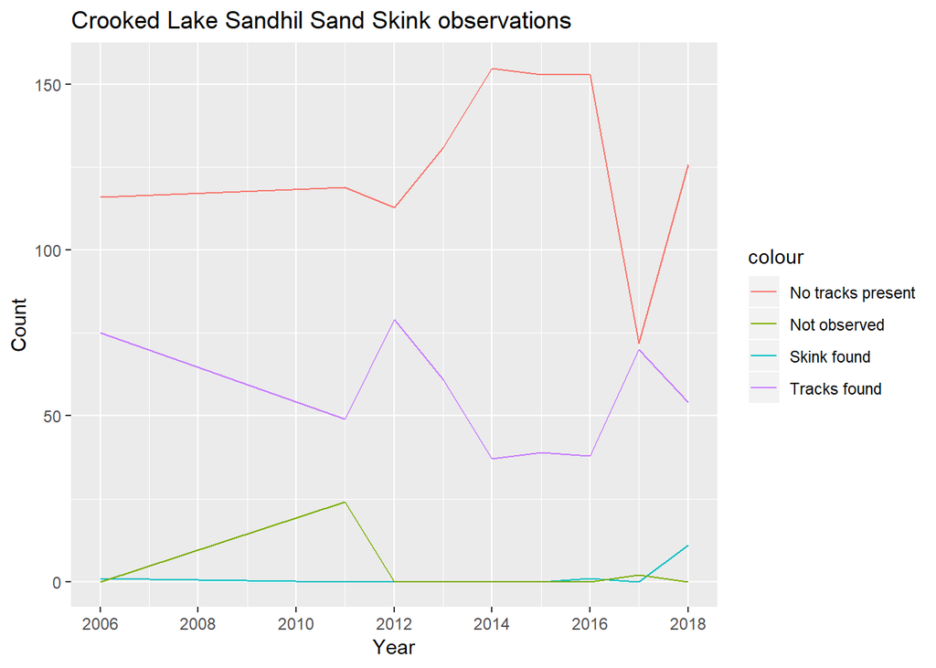

```r
library(ggplot2)

p1 <- ggplot() +
  geom_line(aes(y = NoTracks, x = Year, color="No tracks present"), data = cls1) +
  geom_line(aes(y = Tracks, x = Year, color="Tracks found"), data = cls1)+
  geom_line(aes(y = SkinkPresent, x = Year, color="Skink found"), data = cls1)+
  geom_line(aes(y = NotObserved, x = Year, color="Not observed"), data = cls1)+
  scale_x_continuous(breaks=seq(2006,2018,2)) +
  theme(text=element_text(family="Tahoma"))

p1 + labs(title = "Crooked Lake Sandhil Sand Skink observations", x = "Year", y = "Count")
```

## Crooked Lake Prairie area summary

```r
setwd('F:/UNO/Fall 2018/8086-Data to Decisions/Polk Co Parks/Data/')
prairie <- read.csv("SS_Crooked Lake Prairie.csv", header = TRUE)
str(prairie)
```

```
## 'data.frame':    120 obs. of  66 variables:
##  $ Crooked.Lake.Prairie: Factor w/ 1 level "Crooked Lake Prairie": 1 1 1 1 1 1 1 1 1 1 ...
##  $ Point.and.Quad      : Factor w/ 120 levels "10E","10N","10S",..: 90 89 91 92 110 109 111 112 114 113 ...
##  $ X4.3.2003           : int  0 1 0 0 0 1 0 0 0 1 ...
##  $ X4.10.2003          : int  0 1 0 0 1 1 0 0 0 1 ...
##  $ X4.17.2003          : int  0 1 0 0 1 0 0 0 1 0 ...
##  $ X4.24.2003          : int  0 1 0 0 1 1 0 0 0 1 ...
##  $ X5.1.2003           : int  0 1 0 0 1 0 0 0 0 0 ...
##  $ X5.8.2003           : int  0 1 0 0 1 0 0 0 1 1 ...
##  $ X5.15.2003          : int  0 0 0 0 1 0 0 0 1 1 ...
##  $ X5.22.2003          : int  0 0 0 0 0 0 0 0 1 1 ...
##  $ X4.8.2004           : int  0 1 1 0 0 1 1 0 0 0 ...
##  $ X4.15.2004          : int  0 0 0 0 0 1 0 0 0 1 ...
##  $ X4.22.2004          : int  0 1 0 0 0 1 0 0 0 0 ...
##  $ X4.30.2004          : int  0 1 0 0 0 1 1 1 0 1 ...
```

[output cut: 52 more lines]

Count of observations on sand skins made in each year

## Crooked Lake Prairie plots

[output not shown]

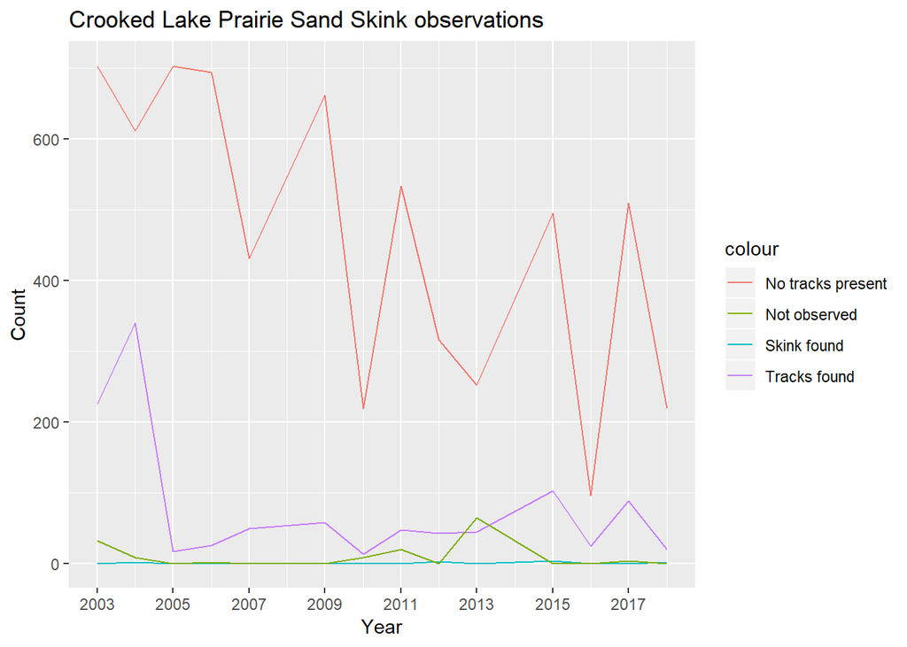

```r
clp1 <- data.frame(Year=numeric(), NoTracks=numeric(), Tracks=numeric(), SkinkPresent=numeric(), NotObserved=numeric())
clp1 <- rbind(clp1, data.frame(Year=2003, NoTracks=count03[1,2], Tracks=count03[2,2], SkinkPresent=0, NotObserved=count03[3,2] ))
clp1 <- rbind(clp1, data.frame(Year=2004, NoTracks=count04[1,2], Tracks=count04[2,2], SkinkPresent=count04[3,2], NotObserved=count04[4,2] ))
clp1 <- rbind(clp1, data.frame(Year=2005, NoTracks=count05[1,2], Tracks=count05[2,2], SkinkPresent=0, NotObserved=0 ))
clp1 <- rbind(clp1, data.frame(Year=2006, NoTracks=count06[1,2], Tracks=count06[2,2], SkinkPresent=0, NotObserved=count06[3,2] ))
clp1 <- rbind(clp1, data.frame(Year=2007, NoTracks=count07[1,2], Tracks=count07[2,2], SkinkPresent=0, NotObserved=0 ))
clp1 <- rbind(clp1, data.frame(Year=2009, NoTracks=count09[1,2], Tracks=count09[2,2], SkinkPresent=0, NotObserved=0 ))
clp1 <- rbind(clp1, data.frame(Year=2010, NoTracks=count10[1,2], Tracks=count10[2,2], SkinkPresent=0, NotObserved=count10[3,2] ))
clp1 <- rbind(clp1, data.frame(Year=2011, NoTracks=count11[1,2], Tracks=count11[2,2], SkinkPresent=0, NotObserved=count11[3,2] ))
clp1 <- rbind(clp1, data.frame(Year=2012, NoTracks=count12[1,2], Tracks=count12[2,2], SkinkPresent=count12[3,2], NotObserved=0 ))
clp1 <- rbind(clp1, data.frame(Year=2013, NoTracks=count13[1,2], Tracks=count13[2,2], SkinkPresent=0, NotObserved=count13[3,2] ))
clp1 <- rbind(clp1, data.frame(Year=2015, NoTracks=count15[1,2], Tracks=count15[2,2], SkinkPresent=count15[3,2], NotObserved=0 ))
clp1 <- rbind(clp1, data.frame(Year=2016, NoTracks=count16[1,2], Tracks=count16[2,2], SkinkPresent=0, NotObserved=0 ))
clp1 <- rbind(clp1, data.frame(Year=2017, NoTracks=count17[1,2], Tracks=count17[2,2], SkinkPresent=0, NotObserved=count17[3,2] ))
clp1 <- rbind(clp1, data.frame(Year=2018, NoTracks=count18[1,2], Tracks=count18[2,2], SkinkPresent=count18[3,2], NotObserved=0 ))

library(ggplot2)

p1 <- ggplot() +
  geom_line(aes(y = NoTracks, x = Year, color="No tracks present"), data = clp1) +
  geom_line(aes(y = Tracks, x = Year, color="Tracks found"), data = clp1)+
  geom_line(aes(y = SkinkPresent, x = Year, color="Skink found"), data = clp1)+
  geom_line(aes(y = NotObserved, x = Year, color="Not observed"), data = clp1)+
  scale_x_continuous(breaks=seq(2003,2018,2)) +
  theme(text=element_text(family="Tahoma"))

p1 + labs(title = "Crooked Lake Prairie Sand Skink observations", x = "Year", y = "Count")
```

## Hickory Lake Scrub area summary

```r
setwd('F:/UNO/Fall 2018/8086-Data to Decisions/Polk Co Parks/Data/')
hickory <- read.csv("SS_Hickory Lake Scrub.csv", header = TRUE)
str(hickory)
```

```
## 'data.frame':    28 obs. of  91 variables:
##  $ Site          : Factor w/ 1 level "Hickory Lake Scrub": 1 1 1 1 1 1 1 1 1 1 ...
##  $ Point.and.Quad: Factor w/ 27 levels "1E","1N","1S",..: 2 1 3 4 6 5 7 8 10 9 ...
##  $ X4.6.2006     : int  1 0 0 1 0 0 1 1 0 0 ...
##  $ X4.13.2006    : int  0 1 0 0 1 0 1 1 0 1 ...
##  $ X4.20.2006    : int  1 0 0 0 0 0 1 1 0 1 ...
##  $ X4.27.2006    : int  0 0 0 1 1 0 1 1 1 0 ...
##  $ X5.4.2006     : int  1 0 0 1 0 0 0 1 0 0 ...
##  $ X5.11.2006    : int  0 0 0 0 1 0 1 1 0 1 ...
##  $ X5.18.2006    : int  0 0 0 0 0 0 1 1 1 0 ...
##  $ X5.25.2006    : int  0 0 0 1 0 0 0 1 0 1 ...
##  $ X4.9.2009     : int  0 0 0 0 0 1 0 0 0 0 ...
##  $ X4.16.2009    : int  0 0 0 0 0 1 0 0 0 0 ...
##  $ X4.23.2009    : int  0 0 0 0 0 0 0 1 1 0 ...
##  $ X4.30.2009    : int  0 0 0 0 1 0 0 0 1 0 ...
```

[output cut: 77 more lines]

Count of observations on sand skins made in each year

## Hickory Lake Scrub plots

[output not shown]

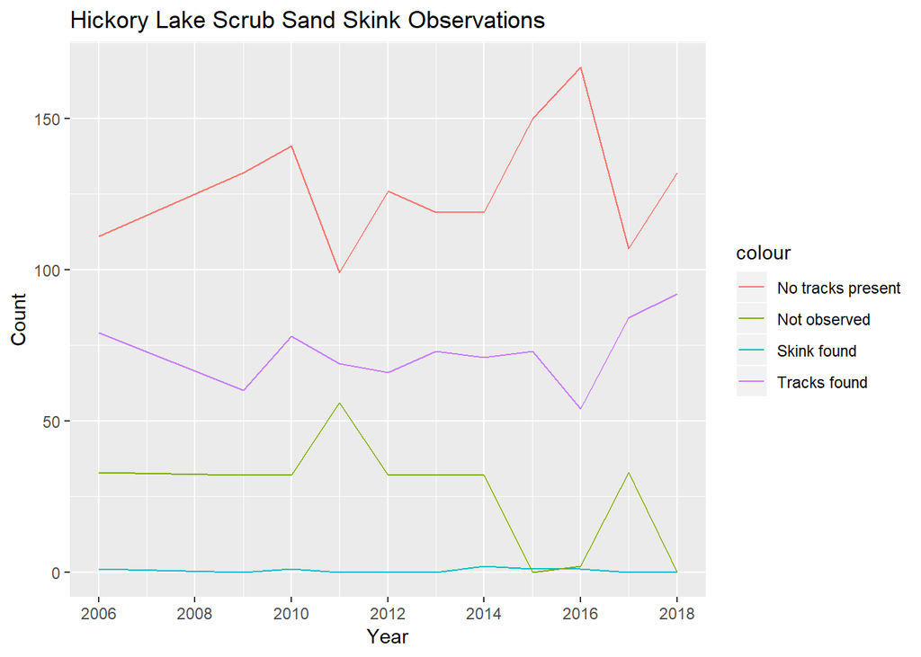

```r
hls1 <- data.frame(Year=numeric(), NoTracks=numeric(), Tracks=numeric(), SkinkPresent=numeric(), NotObserved=numeric())
hls1 <- rbind(hls1, data.frame(Year=2006, NoTracks=count06[1,2], Tracks=count06[2,2], SkinkPresent=count06[3,2], NotObserved=count06[4,2] ))
hls1 <- rbind(hls1, data.frame(Year=2009, NoTracks=count09[1,2], Tracks=count09[2,2], SkinkPresent=0, NotObserved=count09[3,2] ))
hls1 <- rbind(hls1, data.frame(Year=2010, NoTracks=count10[1,2], Tracks=count10[2,2], SkinkPresent=count10[3,2], NotObserved=count10[4,2] ))
hls1 <- rbind(hls1, data.frame(Year=2011, NoTracks=count11[1,2], Tracks=count11[2,2], SkinkPresent=0, NotObserved=count11[3,2] ))
hls1 <- rbind(hls1, data.frame(Year=2012, NoTracks=count12[1,2], Tracks=count12[2,2], SkinkPresent=0, NotObserved=count12[3,2] ))
hls1 <- rbind(hls1, data.frame(Year=2013, NoTracks=count13[1,2], Tracks=count13[2,2], SkinkPresent=0, NotObserved=count13[3,2] ))
hls1 <- rbind(hls1, data.frame(Year=2014, NoTracks=count14[1,2], Tracks=count14[2,2], SkinkPresent=count14[3,2], NotObserved=count14[4,2] ))
hls1 <- rbind(hls1, data.frame(Year=2015, NoTracks=count15[1,2], Tracks=count15[2,2], SkinkPresent=count15[3,2], NotObserved=0 ))
hls1 <- rbind(hls1, data.frame(Year=2016, NoTracks=count16[1,2], Tracks=count16[2,2], SkinkPresent=count16[3,2], NotObserved=count16[4,2] ))
hls1 <- rbind(hls1, data.frame(Year=2017, NoTracks=count17[1,2], Tracks=count17[2,2], SkinkPresent=0, NotObserved=count17[3,2] ))
hls1 <- rbind(hls1, data.frame(Year=2018, NoTracks=count18[1,2], Tracks=count18[2,2], SkinkPresent=0, NotObserved=0 ))

library(ggplot2)

h1 <- ggplot() +
  geom_line(aes(y = NoTracks, x = Year, color="No tracks present"), data = hls1) +
  geom_line(aes(y = Tracks, x = Year, color="Tracks found"), data = hls1)+
  geom_line(aes(y = SkinkPresent, x = Year, color="Skink found"), data = hls1)+
  geom_line(aes(y = NotObserved, x = Year, color="Not observed"), data = hls1)+
  scale_x_continuous(breaks=seq(2006,2018,2)) +
  theme(text=element_text(family="Tahoma"))

h1 + labs(title = "Hickory Lake Scrub Sand Skink Observations", x = "Year", y = "Count")
```

## Crooked Lake West -Lewis area summary

```r
setwd('F:/UNO/Fall 2018/8086-Data to Decisions/Polk Co Parks/Data/')
lewis <- read.csv("SS_Crooked Lake West -Lewis.csv", header = TRUE)
str(lewis)
```

```
## 'data.frame':    56 obs. of  35 variables:
##  $ Site          : Factor w/ 2 levels "Crooked Lake West Lewis",..: 2 2 2 2 2 2 2 2 1 1 ...
##  $ point.and.quad: Factor w/ 56 levels "10E","10N","10S",..: 22 21 23 24 26 25 27 28 30 29 ...
##  $ X4.2.2015     : int  0 1 0 1 0 1 0 0 0 0 ...
##  $ X4.9.2015     : int  0 0 0 1 0 1 0 1 0 1 ...
##  $ X4.16.2015    : int  0 1 0 1 0 0 0 1 0 1 ...
##  $ X4.23.2015    : int  0 1 0 1 0 1 0 1 0 0 ...
##  $ X4.30.2015    : int  1 1 0 0 0 0 0 0 0 0 ...
##  $ X5.7.2015     : int  0 0 0 0 0 1 0 0 0 1 ...
##  $ X5.15.2015    : int  0 1 0 1 0 0 0 0 0 0 ...
##  $ X5.21.2015    : int  0 1 0 1 1 0 0 1 0 1 ...
##  $ X5.28.2015    : int  0 1 0 0 0 1 0 0 0 1 ...
##  $ X4.7.2016     : int  0 1 0 0 NA NA NA NA 0 1 ...
##  $ X4.14.2016    : int  0 1 0 0 NA NA NA NA 0 1 ...
##  $ X4.21.2016    : int  0 1 0 1 NA NA NA NA 1 0 ...
```

[output cut: 21 more lines]

Count of observations on sand skins made in each year

## Crooked Lake West -Lewis plots

[output not shown]

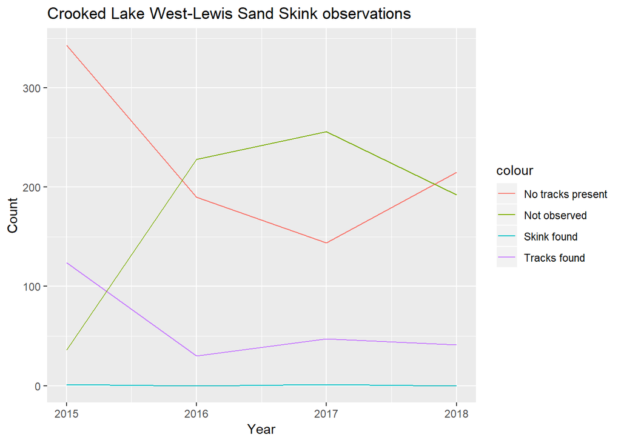

```r
clwl <- data.frame(Year=numeric(), NoTracks=numeric(), Tracks=numeric(), SkinkPresent=numeric(), NotObserved=numeric())
clwl <- rbind(clwl, data.frame(Year=2015, NoTracks=l15[1,2], Tracks=l15[2,2], SkinkPresent=l15[3,2], NotObserved=l15[4,2] ))
clwl <- rbind(clwl, data.frame(Year=2016, NoTracks=l16[1,2], Tracks=l16[2,2], SkinkPresent=0, NotObserved=l16[3,2] ))
clwl <- rbind(clwl, data.frame(Year=2017, NoTracks=l17[1,2], Tracks=l17[2,2], SkinkPresent=l17[3,2], NotObserved=l17[4,2] ))
clwl <- rbind(clwl, data.frame(Year=2018, NoTracks=l18[1,2], Tracks=l18[2,2], SkinkPresent=0, NotObserved=l18[3,2] ))

library(ggplot2)

l1 <- ggplot() +
  geom_line(aes(y = NoTracks, x = Year, color="No tracks present"), data = clwl) +
  geom_line(aes(y = Tracks, x = Year, color="Tracks found"), data = clwl)+
  geom_line(aes(y = SkinkPresent, x = Year, color="Skink found"), data = clwl)+
  geom_line(aes(y = NotObserved, x = Year, color="Not observed"), data = clwl)+
  scale_x_continuous(breaks=seq(2015,2018,1)) +
  theme(text=element_text(family="Tahoma"))

l1 + labs(title = "Crooked Lake West-Lewis Sand Skink observations", x = "Year", y = "Count")
```

## Crooked Lake West -Stuart area summary

```r
setwd('F:/UNO/Fall 2018/8086-Data to Decisions/Polk Co Parks/Data/')
stuart <- read.csv("SS_Crooked Lake West -Stuart.csv", header = TRUE)
str(stuart)
```

```
## 'data.frame':    32 obs. of  35 variables:
##  $ Site          : Factor w/ 1 level "Crooked Lake West Stuart": 1 1 1 1 1 1 1 1 1 1 ...
##  $ Point.and.Quad: Factor w/ 32 levels "1E","1N","1S",..: 2 1 3 4 6 5 7 8 10 9 ...
##  $ X4.2.2015     : int  0 0 0 0 0 0 0 0 1 0 ...
##  $ X4.9.2015     : int  0 0 0 0 0 0 0 0 1 0 ...
##  $ X4.16.2015    : int  0 0 0 0 0 0 0 0 0 0 ...
##  $ X4.23.2015    : int  0 0 0 0 0 0 0 0 1 0 ...
##  $ X4.30.2015    : int  1 0 0 1 0 0 0 0 1 0 ...
##  $ X5.7.2015     : int  1 0 1 0 1 0 1 0 0 0 ...
##  $ X5.14.2015    : int  0 0 1 0 0 0 0 0 1 0 ...
##  $ X5.21.2015    : int  0 0 0 0 0 0 0 0 1 0 ...
##  $ X5.28.2015    : int  0 0 0 0 0 0 0 1 1 0 ...
##  $ X4.7.2016     : int  0 0 0 0 0 0 0 0 0 0 ...
##  $ X4.14.2016    : int  0 0 0 0 0 0 0 0 0 1 ...
##  $ X4.21.2016    : int  0 0 0 0 0 0 0 0 0 1 ...
```

[output cut: 21 more lines]

Count of observations on sand skins made in each year

[output not shown]

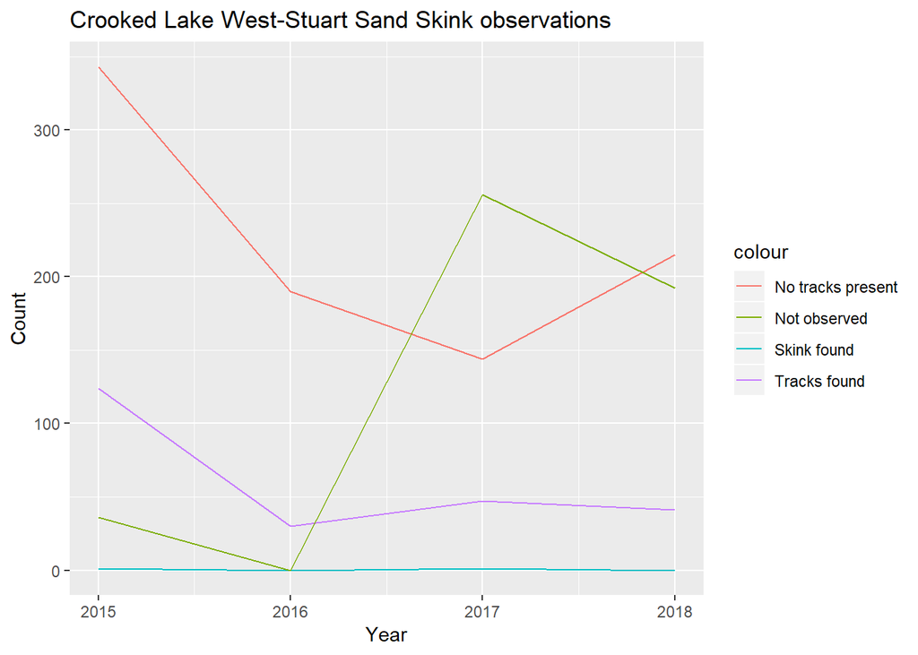

```r
clws <- data.frame(Year=numeric(), NoTracks=numeric(), Tracks=numeric(), SkinkPresent=numeric(), NotObserved=numeric())
clws <- rbind(clws, data.frame(Year=2015, NoTracks=l15[1,2], Tracks=l15[2,2], SkinkPresent=l15[3,2], NotObserved=l15[4,2] ))
clws <- rbind(clws, data.frame(Year=2016, NoTracks=l16[1,2], Tracks=l16[2,2], SkinkPresent=0, NotObserved=0 ))
clws <- rbind(clws, data.frame(Year=2017, NoTracks=l17[1,2], Tracks=l17[2,2], SkinkPresent=l17[3,2], NotObserved=l17[4,2] ))
clws <- rbind(clws, data.frame(Year=2018, NoTracks=l18[1,2], Tracks=l18[2,2], SkinkPresent=0, NotObserved=l18[3,2] ))

library(ggplot2)

s1 <- ggplot() +
  geom_line(aes(y = NoTracks, x = Year, color="No tracks present"), data = clws) +
  geom_line(aes(y = Tracks, x = Year, color="Tracks found"), data = clws)+
  geom_line(aes(y = SkinkPresent, x = Year, color="Skink found"), data = clws)+
  geom_line(aes(y = NotObserved, x = Year, color="Not observed"), data = clws)+
  scale_x_continuous(breaks=seq(2015,2018,1)) +
  theme(text=element_text(family="Tahoma"))

s1 + labs(title = "Crooked Lake West-Stuart Sand Skink observations", x = "Year", y = "Count")
```

# Water Data

```
## 'data.frame':    1568 obs. of  13 variables:
##  $ ï..Index          : int  4 15 24 34 49 55 69 79 89 99 ...
##  $ Sequence          : int  1 4 3 2 4 5 1 3 2 1 ...
##  $ North             : int  0 0 0 1 1 1 1 1 0 0 ...
##  $ Period            : Factor w/ 11 levels "1","2","3","4",..: 1 1 1 1 1 1 1 1 1 1 ...
##  $ Waterbody         : Factor w/ 2 levels "Banana Creek",..: 1 2 2 2 2 2 2 2 2 1 ...
##  $ LabNo             : int  30221 30229 30226 30223 30227 30228 30222 30224 30225 30221 ...
##  $ Sampling.Site.Name: Factor w/ 9 levels "Banana Creek",..: 1 2 3 4 5 6 7 8 9 1 ...
##  $ Date.Collected    : Date, format: "2017-11-07" "2017-11-07" ...
##  $ Parameter         : Factor w/ 16 levels "Chlorophyll a (Corrected)",..: 1 1 1 1 1 1 1 1 1 2 ...
##  $ Unit              : Factor w/ 6 levels "%","deg C","mg/l",..: 5 5 5 5 5 5 5 5 5 6 ...
##  $ Result            : num  110 76.1 31.2 3 8.01 68.6 3 39.2 52.1 173 ...
##  $ DetectionLimit    : num  3 3 3 3 3 3 3 3 3 NA ...
##  $ DQCodes           : Factor w/ 21 levels "A","A I","A J3",..: NA NA NA 12 NA 1 12 NA NA NA ...
```

### Analysis for Total Nitrogen

#### Averages for total nitrogen in the northern route

```
##    Date.Collected AVG(Result)
## 1      2017-11-07      1.2700
## 2      2017-12-05      1.4140
## 3      2018-01-02      1.3900
## 4      2018-02-06      1.5580
## 5      2018-03-06      1.9880
## 6      2018-04-03      2.9560
## 7      2018-05-01      2.4975
## 8      2018-06-05      1.0700
## 9      2018-07-10      0.9400
## 10     2018-08-07      0.9920
## 11     2018-09-04      0.9020
```

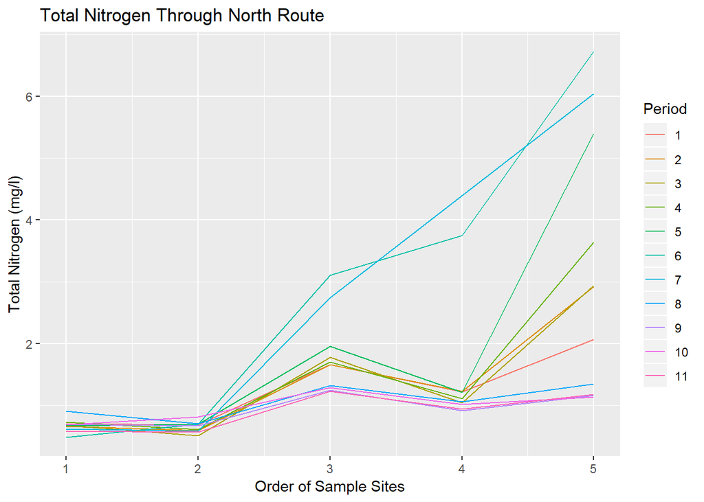

#### Averages for total nitrogen in the southern route

```
##    Date.Collected AVG(Result)
## 1      2017-11-07      2.8150
## 2      2017-12-05      3.3550
## 3      2018-01-02      5.1775
## 4      2018-02-06      2.8200
## 5      2018-03-06      2.6450
## 6      2018-04-03      4.4600
## 7      2018-05-01      5.3900
## 8      2018-06-05      1.6850
## 9      2018-07-10      1.5450
## 10     2018-08-07      1.7975
## 11     2018-09-04      1.7350
```

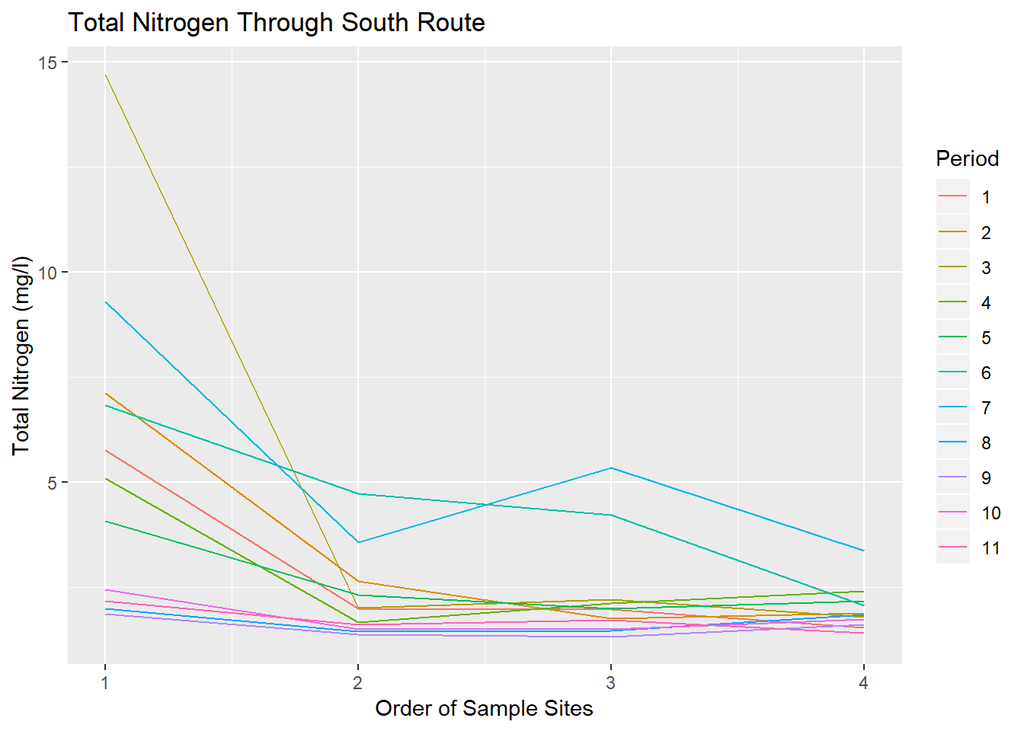

### Analysis for Total Phosphorous

#### Averages for total phosphorus in the northern route

```
##    Date.Collected AVG(Result)
## 1      2017-11-07      0.4884
## 2      2017-12-05      0.4070
## 3      2018-01-02      0.3716
## 4      2018-02-06      0.5102
## 5      2018-03-06      0.5328
## 6      2018-04-03      0.6122
## 7      2018-05-01      0.4220
## 8      2018-06-05      0.6500
## 9      2018-07-10      0.4902
## 10     2018-08-07      0.4314
## 11     2018-09-04      0.3564
```

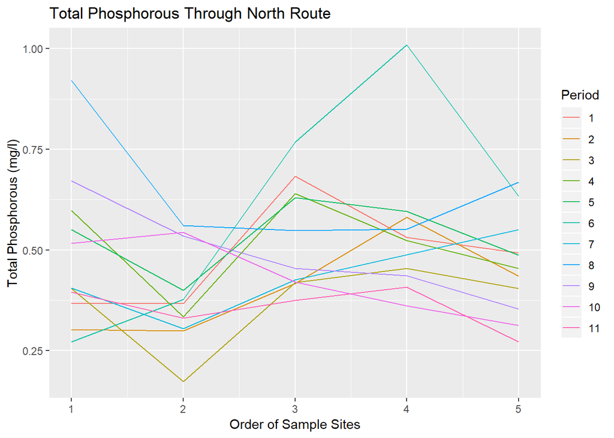

#### Averages for total phosphorus in the southern route

```
##    Date.Collected AVG(Result)
## 1      2017-11-07     0.80800
## 2      2017-12-05     0.79850
## 3      2018-01-02     1.20325
## 4      2018-02-06     0.77800
## 5      2018-03-06     0.82725
## 6      2018-04-03     0.67875
## 7      2018-05-01     0.82150
## 8      2018-06-05     0.62775
## 9      2018-07-10     0.56350
## 10     2018-08-07     0.48850
## 11     2018-09-04     0.42175
```

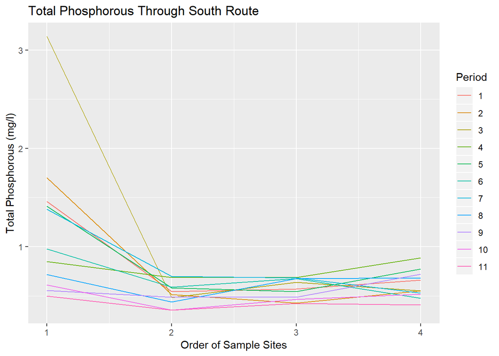